# Model Evaluation and Refinment

## Car Evaluation Sample Project - Part 5

### Car Evaluation Dataset: https://archive.ics.uci.edu/ml/datasets/Car+Evaluation

#### I uploaded the dataset on my github, you can find it here: https://github.com/mmouty/energynds/blob/main/energynds/assets/datasets/auto.csv

#### Data type: csv

# Fifth Step: Model Evaluation and Refinement

#### Prepare the libraries and functions for plotting

```python
from ipywidgets import interact, interactive, fixed, interact_manual
```

```python
def DistributionPlot(RedFunction, BlueFunction, RedName, BlueName, Title):
    width = 12
    height = 10
    plt.figure(figsize=(width, height))

    ax1 = sns.distplot(RedFunction, hist=False, color="r", label=RedName)
    ax2 = sns.distplot(BlueFunction, hist=False, color="b", label=BlueName, ax=ax1)

    plt.title(Title)
    plt.xlabel('Price (in dollars)')
    plt.ylabel('Proportion of Cars')

    plt.show()
    plt.close()
```

```python
def PollyPlot(xtrain, xtest, y_train, y_test, lr,poly_transform):
    width = 12
    height = 10
    plt.figure(figsize=(width, height))


    #training data
    #testing data
    # lr:  linear regression object
    #poly_transform:  polynomial transformation object

    xmax=max([xtrain.values.max(), xtest.values.max()])

    xmin=min([xtrain.values.min(), xtest.values.min()])

    x=np.arange(xmin, xmax, 0.1)


    plt.plot(xtrain, y_train, 'ro', label='Training Data')
    plt.plot(xtest, y_test, 'go', label='Test Data')
    plt.plot(x, lr.predict(poly_transform.fit_transform(x.reshape(-1, 1))), label='Predicted Function')
    plt.ylim([-10000, 60000])
    plt.ylabel('Price')
    plt.legend()
```

### 1. Training and Testing

#### First, we will place the tagret data "price" in a separate dataframe y_data, and remove it from x_data:

```python
y_data = df['price']
```

```python
x_data=df.drop('price',axis=1)
```

#### Now, we will split randomly the data for training and testing

```python
from sklearn.model_selection import train_test_split

#The testing set is 10% of the total dataset
x_train, x_test, y_train, y_test = train_test_split(x_data, y_data, test_size=0.10, random_state=1)


print("number of test samples :", x_test.shape[0])
print("number of training samples:",x_train.shape[0])
```

```
number of test samples : 20
number of training samples: 180
```

#### let's create a linear regression object, and fit the model using the feature "horse-power"

```python
lre=LinearRegression()
```

```python
lre.fit(x_train[['horsepower']], y_train)
```

```
LinearRegression()
```

#### Let's calculate the R^2 on the test data:

```python
lre.score(x_test[['horsepower']], y_test)
```

```
0.5454534032667759
```

#### Let's calculate the R^2 on the train data:

```python
lre.score(x_train[['horsepower']], y_train)
```

```
0.6572826747147018
```

We can see the R^2 is smaller using the test data compared to the training data

### Cross-Validation Score

#### We input the object, the feature ("horsepower"), and the target data (y_data). The parameter 'cv' determines the number of folds. In this case, it is 4.

```python
from sklearn.model_selection import cross_val_score
```

```python
Rcross = cross_val_score(lre, x_data[['horsepower']], y_data, cv=4)
```

The default scoring is R^2. Each element in the array has the average R^2 value for the fold:

```python
Rcross
```

```
array([0.77474062, 0.5172957 , 0.74777703, 0.04701847])
```

#### We can calculate the average and standard deviation of our estimate:

```python
print("The mean of the folds are", Rcross.mean(), "and the standard deviation is" , Rcross.std())
```

```
The mean of the folds are 0.5217079546458679 and the standard deviation is 0.2917543177373881
```

#### We can use negative squared error as a score by setting the parameter 'scoring' metric to 'neg_mean_squared_error'.

```python
-1 * cross_val_score(lre,x_data[['horsepower']], y_data,cv=4,scoring='neg_mean_squared_error')
```

```
array([20648006.60031452, 43733821.19046848, 12543435.0168994 ,
       17587351.09090063])
```

### 2. Overfitting, Underfitting and Model Selection

#### Let's create Multiple Linear Regression objects and train the model using 'horsepower', 'curb-weight', 'engine-size' and 'highway-mpg' as features.

```python
lr = LinearRegression()
lr.fit(x_train[['horsepower', 'curb-weight', 'engine-size', 'highway-mpg']], y_train)
```

```
LinearRegression()
```

#### Prediction using training data:

```python
yhat_train = lr.predict(x_train[['horsepower', 'curb-weight', 'engine-size', 'highway-mpg']])
yhat_train[0:5]
```

```
array([ 7262.8602918 ,   765.64454918, 34524.77168752,  6561.23620348,
        6079.9335172 ])
```

#### Prediction using test data:

```python
yhat_test = lr.predict(x_test[['horsepower', 'curb-weight', 'engine-size', 'highway-mpg']])
yhat_test[0:5]
```

```
array([11098.96538912, 10418.2608313 ,  6479.86875318, 23268.36603459,
        9494.7580886 ])
```

#### Let's perform some model evaluation using our training and testing data separately

```python
import matplotlib.pyplot as plt
%matplotlib inline
import seaborn as sns
```

#### Let's examine the distribution of the predicted values of the training data:

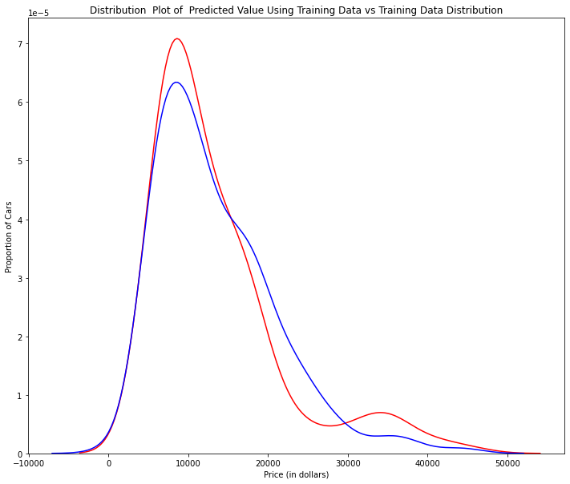

```python
Title = 'Distribution  Plot of  Predicted Value Using Training Data vs Training Data Distribution'
DistributionPlot(y_train, yhat_train, "Actual Values (Train)", "Predicted Values (Train)", Title)
```

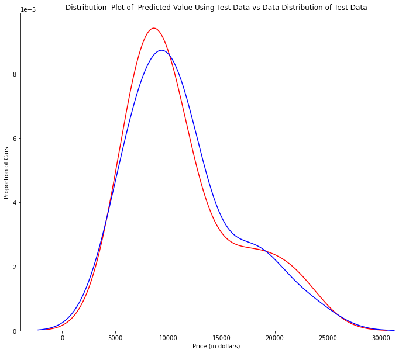

```python
Title='Distribution  Plot of  Predicted Value Using Test Data vs Data Distribution of Test Data'
DistributionPlot(y_test,yhat_test,"Actual Values (Test)","Predicted Values (Test)",Title)
```

```python
from sklearn.preprocessing import PolynomialFeatures
```

#### Let's create a degree 5 polynomial model, and let's use 55 percent of the data for training and the rest for testing:

```python
x_train, x_test, y_train, y_test = train_test_split(x_data, y_data, test_size=0.45, random_state=0)
```

We will perform a degree 5 polynomial transformation on the feature 'horsepower'.

```python
pr = PolynomialFeatures(degree=5)
x_train_pr = pr.fit_transform(x_train[['horsepower']])
x_test_pr = pr.fit_transform(x_test[['horsepower']])
pr
```

```
PolynomialFeatures(degree=5)
```

Now, let's create a Linear Regression model "poly" and train it.

```python
poly = LinearRegression()
poly.fit(x_train_pr, y_train)
```

```
LinearRegression()
```

We can see the output of our model using the method "predict." We assign the values to "yhat".

```python
yhat = poly.predict(x_test_pr)
yhat[0:5]
```

```
array([ 7194.66699567, 10350.09590707, 10991.65504095, 18578.7297168 ,
        3260.96959553])
```

```python
print("Predicted values:", yhat[0:4])
print("True values:", y_test[0:4].values)
```

```
Predicted values: [ 7194.66699567 10350.09590707 10991.65504095 18578.7297168 ]
True values: [ 6575.  9988. 15580. 14399.]
```

We will use the function "PollyPlot" that we defined at the beginning to display the training data, testing data, and the predicted function.

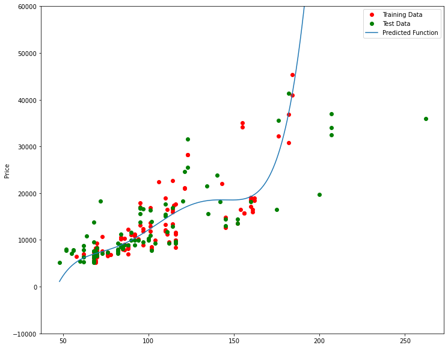

```python
PollyPlot(x_train[['horsepower']], x_test[['horsepower']], y_train, y_test, poly,pr)
```

We see that the estimated function appears to track the data but around 200 horsepower, the function begins to diverge from the data points.

#### R^2 of the training data:

```python
poly.score(x_train_pr, y_train)
```

```
0.7507740781447492
```

#### R^2 of the test data:

```python
poly.score(x_test_pr, y_test)
```

```
-405.19027017426595
```

A negative R^2 is a sign of overfitting.

#### Let's see how the R^2 changes on the test data for different order polynomials and then plot the results:

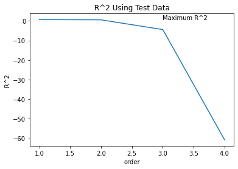

```python
Rsqu_test = []

order = [1, 2, 3, 4]
for n in order:
    pr = PolynomialFeatures(degree=n)

    x_train_pr = pr.fit_transform(x_train[['horsepower']])

    x_test_pr = pr.fit_transform(x_test[['horsepower']])

    lr.fit(x_train_pr, y_train)

    Rsqu_test.append(lr.score(x_test_pr, y_test))

plt.plot(order, Rsqu_test)
plt.xlabel('order')
plt.ylabel('R^2')
plt.title('R^2 Using Test Data')
plt.text(3, 0.75, 'Maximum R^2 ')
```